# STAT UN2103 Section 1 HW2

Rebekah Kim

October 5, 2016

#### Problem 1

1. T-test approach Test $H_0: \beta_1 = 0, H_A: \beta_1 \neq 0$

$t_{calc} = \dfrac{\hat{\beta_1} - \beta_1}{\sqrt{MSE/S_{xx}}} = \dfrac{\hat{\beta_1} - 0}{\sqrt{(SSE/n-2)/S_{xx}}}$

$\hat{\beta}_1 = \dfrac{S_{xy}}{S_{xx}}$

$S_{xy} = \sum\limits_{i=1}^n (x_i-\bar{x})(y_i-\bar{y}) = -927.75$

$S_{xx} = \sum\limits_{i=1}^n (x_i-\bar{x})^2 = 1303$

$\hat{\beta}_1 = \dfrac{-927.75}{1303} = -0.712010744$

MSE = SSE/(n-2)

$SSE = \sum\limits_{i=1}^n (y-\hat{y})^2 = 16.78$

MSE = 1.678

$t_{calc} = \dfrac{-0.712010744 - 0}{\sqrt{1.678/1303}} = -19.84096$

p-value for t-score -19.84 and df 10 is less than 0.00001 < 0.05 (from t-distribution table)

Confidence Interval: $\beta \pm t_{\alpha/2, n-2}\sqrt{MSE/S_{xx}} = -0.712010744 \pm 2.228\sqrt{1.678/1303}--> (-0.635,-0.795)$

We reject the null hypothesis because p-value is less than 0.05 and 0 is not in the confidence interval. There is a statistically significant slope in this study indicating that the concentration of laetisaric acid and fungus growth are statistically related.

2. F-test approach

Test $H_0: \beta_1 = 0, H_A: \beta_1 \neq 0$

$f_{calc} = \dfrac{SSR}{MSE}$

MSE = 1.678 SSR = SST - SSE = 677.35 - 16.78 = 660.57 $f_{calc} = 393.665$

ANOVA table

|  | Df | Sum Sq | Mean Sq | F value |
| --- | --- | --- | --- | --- |
| x | 1 | 660.57 | 660.57 | 393.67 |
| Residuals | 10 | 16.78 | 1.678 |  |
| Total | 11 | 677.35 |  |  |

p-value

```r
1-pf(393.665,1,10)
```

```
## [1] 2.320208e-09
```

We reject the null hypothesis because the p-value is less than 0.05. Same interpretation as part i.

#### Problem 3

```r
x <- c(4, 8, 6, 10, 8, 6, 5, 9, 1, 2)
y <- c(8.70, 17.11, 12.43, 19.47, 15.16, 11.32, 10.28, 16.64, 1.61, 4.49)

# null hypothesis: beta = 2
null_x <- 2*x

# origin model
model <- lm(y~x - 1)
#model <- lm(y~x, offset = 2.00*x)
summary(model)
```

```
##
## Call:
## lm(formula = y ~ x - 1)
##
## Residuals:
##      Min       1Q   Median       3Q      Max
## -1.10518 -0.47301  0.08735  0.58657  1.33651
##
## Coefficients:
##   Estimate Std. Error t value Pr(>|t|)
## x  1.97169    0.03725   52.92 1.54e-12 ***
## ---
## Signif. codes:  0 '***' 0.001 '**' 0.01 '*' 0.05 '.' 0.1 ' ' 1
##
## Residual standard error: 0.7698 on 9 degrees of freedom
## Multiple R-squared:  0.9968, Adjusted R-squared:  0.9964
## F-statistic:  2801 on 1 and 9 DF,  p-value: 1.543e-12
```

```r
t <- (1.97169-2)/(0.03725)
pval_t <- 2*(1-pt(abs(t), 10))
pval_t
```

```
## [1] 0.464795
```

beta = 2 is probably a feasible value of the true slope, since the p-value is >0.05: we fail to reject the null hypothesis (beta = 2).

```r
f_full <- lm(y~x)
anova(f_full)
```

```
## Analysis of Variance Table
##
## Response: y
##           Df  Sum Sq Mean Sq F value    Pr(>F)
## x          1 286.583 286.583  466.54 2.224e-08 ***
## Residuals  8   4.914   0.614
## ---
## Signif. codes:  0 '***' 0.001 '**' 0.01 '*' 0.05 '.' 0.1 ' ' 1
```

```r
f_reduced <- lm(y~x-1)
anova(f_reduced)
```

```
## Analysis of Variance Table
##
## Response: y
##           Df  Sum Sq Mean Sq F value    Pr(>F)
## x          1 1659.98 1659.98    2801 1.543e-12 ***
## Residuals  9    5.33    0.59
## ---
## Signif. codes:  0 '***' 0.001 '**' 0.01 '*' 0.05 '.' 0.1 ' ' 1
```

```r
fcalc <- (5.33-4.914)/(9-8)/(4.914/8)
pval_f <- 1- pf(fcalc, 1, 8)
pval_f
```

```
## [1] 0.434379
```

$SSE_F = 4.914, df_F = 8, SSE_R = 5.33, df_R = 9$ $f_{calc} = (5.33-4.914)/(9-8)/(4.914/8)$

We fail to reject null hypothesis (Beta0 is o, or there is no intercept) because p-value > 0.05

The model(2) may be more appropriate for this dataset because both models (2)(3) are valid but model(2) is simpler and have less parameters to deal with (easier to use).

#### Problem 4

```r
Husband <- c(186,180,160,186,163,172,192,170,174,191,182,178,181,168,162,188,168,183,188,166,180,176,185,169,182,162,169,176,180,157,170,186,180,188,153,179,175,165,156,185,172,166,179,181,176,170,165,183,162,192,185,163,185,170,176,176,160,167,157,180,172,184,185,165,181,170,161,188,181,156,161,152,179,170,170,165,165,169,171,192,176,168,169,184,171,161,185,184,179,184,175,173,164,181,187,181)
Wife <-  c(175,168,154,166,162,152,179,163,172,170,170,147,165,162,154,166,167,174,173,164,163,163,171,161,167,160,165,167,175,157,172,181,166,181,148,169,170,157,162,174,168,162,159,155,171,159,164,175,156,180,167,157,167,157,168,167,145,156,153,162,156,174,160,152,175,169,149,176,165,143,158,141,160,149,160,148,154,171,165,175,161,162,162,176,160,158,175,174,168,177,158,161,146,168,178,170)
```

```r
heights <- lm(Husband~Wife)
summary(heights)
```

```
##
## Call:
## lm(formula = Husband ~ Wife)
##
## Residuals:
##      Min       1Q   Median       3Q      Max
## -16.7438  -4.2838  -0.1615   4.2562  17.7500
##
## Coefficients:
##             Estimate Std. Error t value Pr(>|t|)
## (Intercept) 37.81005   11.93231   3.169  0.00207 **
## Wife         0.83292    0.07269  11.458  < 2e-16 ***
## ---
## Signif. codes:  0 '***' 0.001 '**' 0.01 '*' 0.05 '.' 0.1 ' ' 1
##
## Residual standard error: 6.468 on 94 degrees of freedom
## Multiple R-squared:  0.5828, Adjusted R-squared:  0.5783
## F-statistic: 131.3 on 1 and 94 DF,  p-value: < 2.2e-16
```

```r
cor(Husband, Wife)
```

```
## [1] 0.7633864
```

```r
cor.test(Husband, Wife)
```

```
##
##  Pearson's product-moment correlation
##
## data:  Husband and Wife
## t = 11.458, df = 94, p-value < 2.2e-16
## alternative hypothesis: true correlation is not equal to 0
## 95 percent confidence interval:
##  0.6646193 0.8359341
## sample estimates:
##       cor
## 0.7633864
```

The confidence intervals do not include 0. The population correlation coefficient most likely differs from zero.

#### Problem 5

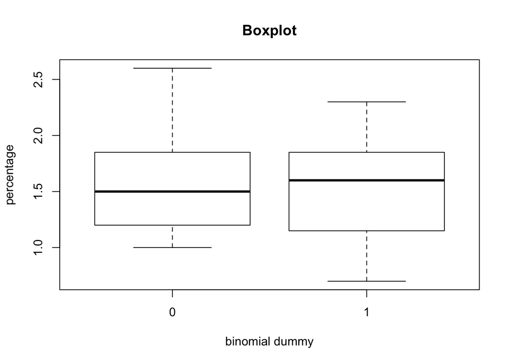

```r
H <- c(1.2, .9, .7, 1.0, 1.7, 1.7, 1.1, .9, 1.7,
1.9, 1.3, 2.1, 1.6, 1.8, 1.4, 1.3, 1.9, 1.6,
.8, 2.0, 1.7, 1.6, 2.3, 2.0)
P <- c(1.6, 1.5, 1.1, 2.1, 1.5, 1.3, 1.0, 2.6)

#response
y <- c(H, P)

#dummy var
x <- c(rep(1,length(H)), rep(0,length(P)))

#visualization
boxplot(y~x, main="Boxplot", ylab="percentage", xlab="binomial dummy")
```

```r
summary(lm(y~x))
```

```
##
## Call:
## lm(formula = y ~ x)
##
## Residuals:
##      Min       1Q   Median       3Q      Max
## -0.80833 -0.33333  0.05208  0.31667  1.01250
##
## Coefficients:
##             Estimate Std. Error t value Pr(>|t|)
## (Intercept)  1.58750    0.16466   9.641 1.06e-10 ***
## x           -0.07917    0.19013  -0.416     0.68
## ---
## Signif. codes:  0 '***' 0.001 '**' 0.01 '*' 0.05 '.' 0.1 ' ' 1
##
## Residual standard error: 0.4657 on 30 degrees of freedom
## Multiple R-squared:  0.005746,   Adjusted R-squared:  -0.0274
## F-statistic: 0.1734 on 1 and 30 DF,  p-value: 0.6801
```

```r
t.test(H,P,var.equal = TRUE)
```

```
##
##  Two Sample t-test
##
## data:  H and P
## t = -0.41638, df = 30, p-value = 0.6801
## alternative hypothesis: true difference in means is not equal to 0
## 95 percent confidence interval:
##  -0.4674695  0.3091362
## sample estimates:
## mean of x mean of y
##  1.508333  1.587500
```

Average fabric extensibility probably does not differ per group because we fail to reject null hypothesis (p = 0.6801 > 0.05)

```r
quality_model <- lm(y~x)
#prediction
x_data <- data.frame(x=c(1,0))
predict(lm(y~x), newdata= x_data, interval="confidence")
```

```
##        fit      lwr      upr
## 1 1.508333 1.314182 1.702485
## 2 1.587500 1.251220 1.923780
```